# Home Credit Default Risk - Modeling Notebook

Heidi Hatch

March 22, 2026

## 0.1 Overview

This notebook develops predictive models for the Home Credit Default Risk project. The goal is to predict the probability that a client will have repayment difficulties. Because the target is highly imbalanced, model comparison focuses on AUC rather than accuracy alone.

The notebook proceeds in five stages:

1. Establish a baseline benchmark.
2. Compare several candidate models using cross-validation.
3. Test class-imbalance strategies.
4. Tune the best-performing model efficiently.
5. Train a final model and generate a Kaggle submission.

```r
library(tidyverse)
library(readr)
library(caret)
library(pROC)
library(xgboost)
library(randomForest)
set.seed(123)
```

## 0.2 Load data

```r
bureau <- read_csv("/Users/heidihatch/Desktop/Heidi GitHub/Home_Credit_repo/bureau.csv", show_col_types = FALSE)
prev   <- read_csv("/Users/heidihatch/Desktop/Heidi GitHub/Home_Credit_repo/previous_application.csv", show_col_types = FALSE)
insta  <- read_csv("/Users/heidihatch/Desktop/Heidi GitHub/Home_Credit_repo/installments_payments.csv", show_col_types = FALSE)
cc_balance <- read_csv("/Users/heidihatch/Desktop/Heidi GitHub/Home_Credit_repo/credit_card_balance.csv", show_col_types = FALSE)
pos_cash_balance <- read_csv("/Users/heidihatch/Desktop/Heidi GitHub/Home_Credit_repo/POS_CASH_balance.csv", show_col_types = FALSE)

train_raw <- read_csv("/Users/heidihatch/Desktop/Heidi GitHub/Home_Credit_repo/application_train.csv", show_col_types = FALSE)
test_raw  <- read_csv("/Users/heidihatch/Desktop/Heidi GitHub/Home_Credit_repo/application_test.csv", show_col_types = FALSE)
```

## 0.3 Create supplementary features

To improve predictive performance, this notebook aggregates customer-level information from the supplementary tables. These engineered features summarize external credit history, installment payment behavior, credit card utilization, and POS cash performance.

```r
safe_div <- function(num, den) {
  ifelse(is.na(den) | den == 0, NA_real_, num / den)
}
```

### 0.3.1 Bureau aggregation

```r
bureau_agg <- bureau %>%
  mutate(
    is_active = if_else(CREDIT_ACTIVE == "Active", 1, 0, missing = 0),
    debt_ratio = safe_div(AMT_CREDIT_SUM_DEBT, AMT_CREDIT_SUM),
    overdue_amt = coalesce(AMT_CREDIT_SUM_OVERDUE, AMT_CREDIT_MAX_OVERDUE)
  ) %>%
  group_by(SK_ID_CURR) %>%
  summarise(
    bureau_n_records = n(),
    bureau_frac_active = mean(is_active, na.rm = TRUE),
    bureau_max_overdue = suppressWarnings(max(overdue_amt, na.rm = TRUE)),
    bureau_mean_debt_ratio = mean(debt_ratio, na.rm = TRUE),
    bureau_mean_credit_sum = mean(AMT_CREDIT_SUM, na.rm = TRUE),
    bureau_mean_debt = mean(AMT_CREDIT_SUM_DEBT, na.rm = TRUE),
    bureau_any_overdue = as.integer(any(overdue_amt > 0, na.rm = TRUE)),
    .groups = "drop"
  ) %>%
  mutate(
    bureau_max_overdue = ifelse(is.infinite(bureau_max_overdue), NA_real_, bureau_max_overdue)
  )
```

### 0.3.2 Installments aggregation

```r
inst_agg <- insta %>%
  mutate(
    days_late = DAYS_ENTRY_PAYMENT - DAYS_INSTALMENT,
    is_late = if_else(days_late > 0, 1, 0, missing = 0),
    dpd = pmax(days_late, 0),
    pay_to_inst = safe_div(AMT_PAYMENT, AMT_INSTALMENT)
  ) %>%
  group_by(SK_ID_CURR) %>%
  summarise(
    inst_n_payments = n(),
    inst_pct_late = mean(is_late, na.rm = TRUE),
    inst_avg_dpd = mean(dpd, na.rm = TRUE),
    inst_max_dpd = suppressWarnings(max(dpd, na.rm = TRUE)),
    inst_mean_pay_to_inst = mean(pay_to_inst, na.rm = TRUE),
    inst_median_pay_to_inst = median(pay_to_inst, na.rm = TRUE),
    inst_mean_payment = mean(AMT_PAYMENT, na.rm = TRUE),
    inst_mean_instalment = mean(AMT_INSTALMENT, na.rm = TRUE),
    .groups = "drop"
  ) %>%
  mutate(
    inst_max_dpd = ifelse(is.infinite(inst_max_dpd), NA_real_, inst_max_dpd)
  )
```

### 0.3.3 Credit card aggregation

```r
cc_agg <- cc_balance %>%
  mutate(
    cc_util = safe_div(AMT_BALANCE, AMT_CREDIT_LIMIT_ACTUAL)
  ) %>%
  group_by(SK_ID_CURR) %>%
  summarise(
    cc_n_months = n(),
    cc_months_span = max(MONTHS_BALANCE, na.rm = TRUE) - min(MONTHS_BALANCE, na.rm = TRUE),
    cc_mean_balance = mean(AMT_BALANCE, na.rm = TRUE),
    cc_max_balance = suppressWarnings(max(AMT_BALANCE, na.rm = TRUE)),
    cc_mean_limit = mean(AMT_CREDIT_LIMIT_ACTUAL, na.rm = TRUE),
    cc_mean_util = mean(cc_util, na.rm = TRUE),
    cc_max_util = suppressWarnings(max(cc_util, na.rm = TRUE)),
    cc_mean_payment = mean(AMT_PAYMENT_CURRENT, na.rm = TRUE),
    cc_mean_dpd = mean(SK_DPD, na.rm = TRUE),
    cc_max_dpd = suppressWarnings(max(SK_DPD, na.rm = TRUE)),
    cc_mean_dpd_def = mean(SK_DPD_DEF, na.rm = TRUE),
    cc_max_dpd_def = suppressWarnings(max(SK_DPD_DEF, na.rm = TRUE)),
    cc_any_dpd = as.integer(any(SK_DPD > 0, na.rm = TRUE)),
    .groups = "drop"
  ) %>%
  mutate(
    cc_max_balance = ifelse(is.infinite(cc_max_balance), NA_real_, cc_max_balance),
    cc_max_util = ifelse(is.infinite(cc_max_util), NA_real_, cc_max_util),
    cc_max_dpd = ifelse(is.infinite(cc_max_dpd), NA_real_, cc_max_dpd),
    cc_max_dpd_def = ifelse(is.infinite(cc_max_dpd_def), NA_real_, cc_max_dpd_def)
  )
```

### 0.3.4 POS cash aggregation

```r
pos_agg <- pos_cash_balance %>%
  mutate(
    pos_is_completed = if_else(NAME_CONTRACT_STATUS == "Completed", 1, 0, missing = 0),
    pos_is_active = if_else(NAME_CONTRACT_STATUS == "Active", 1, 0, missing = 0)
  ) %>%
  group_by(SK_ID_CURR) %>%
  summarise(
    pos_n_months = n(),
    pos_months_span = max(MONTHS_BALANCE, na.rm = TRUE) - min(MONTHS_BALANCE, na.rm = TRUE),
    pos_mean_dpd = mean(SK_DPD, na.rm = TRUE),
    pos_max_dpd = suppressWarnings(max(SK_DPD, na.rm = TRUE)),
    pos_mean_dpd_def = mean(SK_DPD_DEF, na.rm = TRUE),
    pos_max_dpd_def = suppressWarnings(max(SK_DPD_DEF, na.rm = TRUE)),
    pos_any_dpd = as.integer(any(SK_DPD > 0, na.rm = TRUE)),
    pos_mean_cnt_inst = mean(CNT_INSTALMENT, na.rm = TRUE),
    pos_mean_cnt_inst_future = mean(CNT_INSTALMENT_FUTURE, na.rm = TRUE),
    pos_frac_completed = mean(pos_is_completed, na.rm = TRUE),
    pos_frac_active = mean(pos_is_active, na.rm = TRUE),
    .groups = "drop"
  ) %>%
  mutate(
    pos_max_dpd = ifelse(is.infinite(pos_max_dpd), NA_real_, pos_max_dpd),
    pos_max_dpd_def = ifelse(is.infinite(pos_max_dpd_def), NA_real_, pos_max_dpd_def)
  )
```

## 0.4 Join base and supplementary data

```r
train_full <- train_raw %>%
  left_join(bureau_agg, by = "SK_ID_CURR") %>%
  left_join(inst_agg,   by = "SK_ID_CURR") %>%
  left_join(cc_agg,     by = "SK_ID_CURR") %>%
  left_join(pos_agg,    by = "SK_ID_CURR")

test_full <- test_raw %>%
  left_join(bureau_agg, by = "SK_ID_CURR") %>%
  left_join(inst_agg,   by = "SK_ID_CURR") %>%
  left_join(cc_agg,     by = "SK_ID_CURR") %>%
  left_join(pos_agg,    by = "SK_ID_CURR")
```

## 0.5 Additional application-level feature engineering

```r
engineer_app_features <- function(df) {
  ext_cols <- select(df, starts_with("EXT_SOURCE"))

  ext_mean <- rowMeans(ext_cols, na.rm = TRUE)
  ext_mean[is.nan(ext_mean)] <- NA_real_

  ext_max <- do.call(pmax, c(ext_cols, na.rm = TRUE))
  ext_min <- do.call(pmin, c(ext_cols, na.rm = TRUE))

  ext_max[is.infinite(ext_max)] <- NA_real_
  ext_min[is.infinite(ext_min)] <- NA_real_

  df %>%
    mutate(
      DAYS_EMPLOYED = ifelse(DAYS_EMPLOYED == 365243, NA, DAYS_EMPLOYED),
      AGE_YEARS = abs(DAYS_BIRTH) / 365,
      EMPLOYED_YEARS = abs(DAYS_EMPLOYED) / 365,
      CREDIT_TO_INCOME = safe_div(AMT_CREDIT, AMT_INCOME_TOTAL),
      ANNUITY_TO_INCOME = safe_div(AMT_ANNUITY, AMT_INCOME_TOTAL),
      CREDIT_TO_GOODS = safe_div(AMT_CREDIT, AMT_GOODS_PRICE),
      ANNUITY_TO_CREDIT = safe_div(AMT_ANNUITY, AMT_CREDIT),
      INCOME_PER_CHILD = safe_div(AMT_INCOME_TOTAL, 1 + CNT_CHILDREN),
      EXT_SOURCE_MEAN = ext_mean,
      EXT_SOURCE_MAX = ext_max,
      EXT_SOURCE_MIN = ext_min
    )
}

train_full <- engineer_app_features(train_full)
test_full  <- engineer_app_features(test_full)
```

## 0.6 Data cleaning for modeling

For modeling, missing numeric values are replaced with 0 as a simple baseline preprocessing strategy. The target is recoded into descriptive factor levels because `caret`’s AUC functions work more reliably with valid class names than with `"0"` and `"1"`.

This section also fixes the cross-validation error caused by rare categorical levels appearing in validation folds but not in the corresponding training folds. To avoid that problem, rare categories are collapsed, character columns are converted to factors, and dummy variables are created before model training so every fold uses a consistent predictor matrix.

```r
replace_inf_na_with_zero <- function(df) {
  df %>%
    mutate(across(where(is.numeric), ~ ifelse(is.infinite(.), NA_real_, .))) %>%
    mutate(across(where(is.numeric), ~ ifelse(is.nan(.), NA_real_, .))) %>%
    mutate(across(where(is.numeric), ~ replace_na(., 0)))
}

train_full_processed <- replace_inf_na_with_zero(train_full)
test_full_processed  <- replace_inf_na_with_zero(test_full)

train_full_processed$TARGET <- factor(
  ifelse(train_full_processed$TARGET == 1, "Default", "NoDefault"),
  levels = c("NoDefault", "Default")
)
```

## 0.7 Compare application-only vs supplementary feature sets

To evaluate whether the extra tables add predictive value, this notebook compares: - a base feature set using application data only - an expanded feature set including aggregated supplementary features

```r
supp_cols <- c(
  names(bureau_agg)[names(bureau_agg) != "SK_ID_CURR"],
  names(inst_agg)[names(inst_agg) != "SK_ID_CURR"],
  names(cc_agg)[names(cc_agg) != "SK_ID_CURR"],
  names(pos_agg)[names(pos_agg) != "SK_ID_CURR"]
)

base_predictors <- setdiff(names(train_raw), c("SK_ID_CURR", "TARGET"))
base_predictors <- union(base_predictors, c(
  "AGE_YEARS", "EMPLOYED_YEARS", "CREDIT_TO_INCOME", "ANNUITY_TO_INCOME",
  "CREDIT_TO_GOODS", "ANNUITY_TO_CREDIT", "INCOME_PER_CHILD",
  "EXT_SOURCE_MEAN", "EXT_SOURCE_MAX", "EXT_SOURCE_MIN"
))
base_predictors <- intersect(base_predictors, names(train_full_processed))

full_predictors <- setdiff(names(train_full_processed), c("SK_ID_CURR", "TARGET"))
```

## 0.8 Prepare predictors for cross-validation-safe modeling

```r
train_full_processed <- train_full_processed %>%
  mutate(
    CODE_GENDER = ifelse(CODE_GENDER == "XNA", NA, CODE_GENDER),
    NAME_INCOME_TYPE = ifelse(NAME_INCOME_TYPE %in% c("Pensioner", "Unemployed"),
                              "Other",
                              NAME_INCOME_TYPE)
  ) %>%
  mutate(across(where(is.character), as.factor))

test_full_processed <- test_full_processed %>%
  mutate(
    CODE_GENDER = ifelse(CODE_GENDER == "XNA", NA, CODE_GENDER),
    NAME_INCOME_TYPE = ifelse(NAME_INCOME_TYPE %in% c("Pensioner", "Unemployed"),
                              "Other",
                              NAME_INCOME_TYPE)
  ) %>%
  mutate(across(where(is.character), as.factor))

factor_cols <- names(train_full_processed)[sapply(train_full_processed, is.factor)]

for (col in factor_cols) {
  if (col != "TARGET") {
    test_full_processed[[col]] <- factor(
      test_full_processed[[col]],
      levels = levels(train_full_processed[[col]])
    )
  }
}

dummy_obj_base <- dummyVars(
  ~ .,
  data = train_full_processed[, base_predictors, drop = FALSE],
  fullRank = TRUE
)

x_base <- predict(dummy_obj_base, newdata = train_full_processed[, base_predictors, drop = FALSE]) %>%
  as.data.frame()

test_x_base <- predict(dummy_obj_base, newdata = test_full_processed[, base_predictors, drop = FALSE]) %>%
  as.data.frame()

dummy_obj_full <- dummyVars(
  ~ .,
  data = train_full_processed[, full_predictors, drop = FALSE],
  fullRank = TRUE
)

x_full <- predict(dummy_obj_full, newdata = train_full_processed[, full_predictors, drop = FALSE]) %>%
  as.data.frame()

test_x_full <- predict(dummy_obj_full, newdata = test_full_processed[, full_predictors, drop = FALSE]) %>%
  as.data.frame()

y <- factor(train_full_processed$TARGET, levels = c("NoDefault", "Default"))

x_base[is.na(x_base)] <- 0
x_full[is.na(x_full)] <- 0
test_x_base[is.na(test_x_base)] <- 0
test_x_full[is.na(test_x_full)] <- 0

nzv_base <- nearZeroVar(x_base)
if (length(nzv_base) > 0) {
  x_base <- x_base[, -nzv_base, drop = FALSE]
  test_x_base <- test_x_base[, colnames(x_base), drop = FALSE]
}

nzv_full <- nearZeroVar(x_full)
if (length(nzv_full) > 0) {
  x_full <- x_full[, -nzv_full, drop = FALSE]
  test_x_full <- test_x_full[, colnames(x_full), drop = FALSE]
}

logit_vars <- c(
  "EXT_SOURCE_1",
  "EXT_SOURCE_2",
  "EXT_SOURCE_3",
  "EXT_SOURCE_MEAN",
  "CREDIT_TO_INCOME",
  "ANNUITY_TO_INCOME",
  "AGE_YEARS",
  "EMPLOYED_YEARS",
  "AMT_CREDIT",
  "AMT_ANNUITY",
  "AMT_INCOME_TOTAL",
  "bureau_frac_active",
  "bureau_mean_debt_ratio",
  "inst_pct_late",
  "inst_avg_dpd",
  "cc_mean_util",
  "pos_mean_dpd"
)

logit_vars <- intersect(logit_vars, names(train_full_processed))

dummy_obj_logit <- dummyVars(
  ~ .,
  data = train_full_processed[, logit_vars, drop = FALSE],
  fullRank = TRUE
)

x_logit <- predict(dummy_obj_logit, newdata = train_full_processed[, logit_vars, drop = FALSE]) %>%
  as.data.frame()

test_x_logit <- predict(dummy_obj_logit, newdata = test_full_processed[, logit_vars, drop = FALSE]) %>%
  as.data.frame()

x_logit[is.na(x_logit)] <- 0
test_x_logit[is.na(test_x_logit)] <- 0

nzv_logit <- nearZeroVar(x_logit)
if (length(nzv_logit) > 0) {
  x_logit <- x_logit[, -nzv_logit, drop = FALSE]
  test_x_logit <- test_x_logit[, colnames(x_logit), drop = FALSE]
}
```

## 0.9 Baseline benchmark

Because the target is highly imbalanced, a majority-class classifier can achieve high accuracy simply by always predicting the non-default class. This makes accuracy misleading. AUC provides a better benchmark because it evaluates ranking ability rather than raw class frequency.

```r
baseline_rate <- mean(y == "Default")
baseline_accuracy <- mean(y == "NoDefault")
baseline_auc <- 0.5

cat("Baseline majority-class accuracy:", round(baseline_accuracy, 4), "\n")
```

```
## Baseline majority-class accuracy: 0.9193
```

```r
cat("Baseline AUC:", round(baseline_auc, 4), "\n")
```

```
## Baseline AUC: 0.5
```

The baseline model achieves high accuracy because most applicants do not default. However, its AUC is 0.50, meaning it has no ability to distinguish risky from non-risky applicants. Any useful predictive model should improve meaningfully on this AUC benchmark.

## 0.10 Cross-validation setup

```r
ctrl_cv <- trainControl(
  method = "cv",
  number = 3,
  classProbs = TRUE,
  summaryFunction = twoClassSummary,
  savePredictions = "final"
)

ctrl_down <- trainControl(
  method = "cv",
  number = 3,
  classProbs = TRUE,
  summaryFunction = twoClassSummary,
  sampling = "down",
  savePredictions = "final"
)

ctrl_up <- trainControl(
  method = "cv",
  number = 3,
  classProbs = TRUE,
  summaryFunction = twoClassSummary,
  sampling = "up",
  savePredictions = "final"
)
```

## 0.11 Candidate models

This notebook compares three model families: - Logistic regression - Random forest - Gradient boosting with XGBoost

These models represent increasing flexibility and complexity. Performance is evaluated using cross-validated AUC where possible. Logistic regression is fit on a reduced, stable feature set, while the tree-based models use the full dummy-expanded matrix.

### 0.11.1 Logistic regression

```r
set.seed(123)
model_lr <- train(
  x = x_logit,
  y = y,
  method = "glm",
  family = "binomial",
  metric = "ROC",
  trControl = ctrl_cv
)
```

### 0.11.2 Random forest

```r
set.seed(123)

rf_sample_n <- min(20000, nrow(x_full))
rf_idx <- sample(seq_len(nrow(x_full)), rf_sample_n)

x_rf <- x_full[rf_idx, , drop = FALSE]
y_rf <- y[rf_idx]

rf_grid <- expand.grid(mtry = max(2, floor(sqrt(ncol(x_rf)) / 2)))

ctrl_fast <- trainControl(
  method = "cv",
  number = 3,
  classProbs = TRUE,
  summaryFunction = twoClassSummary
)

model_rf_full <- train(
  x = x_rf,
  y = y_rf,
  method = "rf",
  metric = "ROC",
  tuneGrid = rf_grid,
  ntree = 100,
  trControl = ctrl_fast
)
```

### 0.11.3 XGBoost

```r
y_num <- ifelse(y == levels(y)[2], 1, 0)
x_mat <- data.matrix(x_full)

set.seed(123)
idx <- sample(seq_len(nrow(x_mat)), size = 0.8 * nrow(x_mat))

x_train <- x_mat[idx, ]
x_valid <- x_mat[-idx, ]

y_train <- y_num[idx]
y_valid <- y_num[-idx]

dtrain <- xgb.DMatrix(x_train, label = y_train)
dvalid <- xgb.DMatrix(x_valid, label = y_valid)

params <- list(
  objective = "binary:logistic",
  eval_metric = "auc",
  max_depth = 3,
  eta = 0.1,
  subsample = 0.8,
  colsample_bytree = 0.8,
  min_child_weight = 1
)

set.seed(123)
model_xgb_full <- xgb.train(
  params = params,
  data = dtrain,
  nrounds = 150,
  verbose = 0
)

pred_valid <- predict(model_xgb_full, dvalid)
auc_valid <- pROC::auc(y_valid, pred_valid)
auc_valid
```

```
## Area under the curve: 0.7765
```

## 0.12 Compare candidate models

```r
results_raw <- resamples(list(
  Logistic = model_lr,
  RF_Full = model_rf_full
))

summary(results_raw)
```

```
##
## Call:
## summary.resamples(object = results_raw)
##
## Models: Logistic, RF_Full
## Number of resamples: 3
##
## ROC
##               Min.   1st Qu.    Median      Mean   3rd Qu.      Max. NA's
## Logistic 0.7231345 0.7238421 0.7245498 0.7250850 0.7260603 0.7275708    0
## RF_Full  0.7182032 0.7192358 0.7202685 0.7231888 0.7256815 0.7310946    0
##
## Sens
##               Min.   1st Qu.    Median      Mean   3rd Qu.      Max. NA's
## Logistic 0.9996498 0.9996657 0.9996816 0.9996852 0.9997029 0.9997241    0
## RF_Full  0.9998368 0.9999184 1.0000000 0.9999456 1.0000000 1.0000000    0
##
## Spec
##                 Min.     1st Qu.      Median        Mean     3rd Qu.
## Logistic 0.002296073 0.002416918 0.002537764 0.002860020 0.003141994
## RF_Full  0.003710575 0.003714024 0.003717472 0.004331303 0.004641667
##                 Max. NA's
## Logistic 0.003746224    0
## RF_Full  0.005565863    0
```

```r
model_compare <- tibble(
  Model = c("Logistic Regression", "Random Forest - Sampled", "XGBoost - Holdout"),
  AUC = c(
    max(model_lr$results$ROC),
    max(model_rf_full$results$ROC),
    as.numeric(auc_valid)
  )
) %>%
  arrange(desc(AUC))

model_compare
```

| Model | AUC |
| --- | --- |
| XGBoost - Holdout | 0.7765058 |
| Logistic Regression | 0.7250850 |
| Random Forest - Sampled | 0.7231888 |

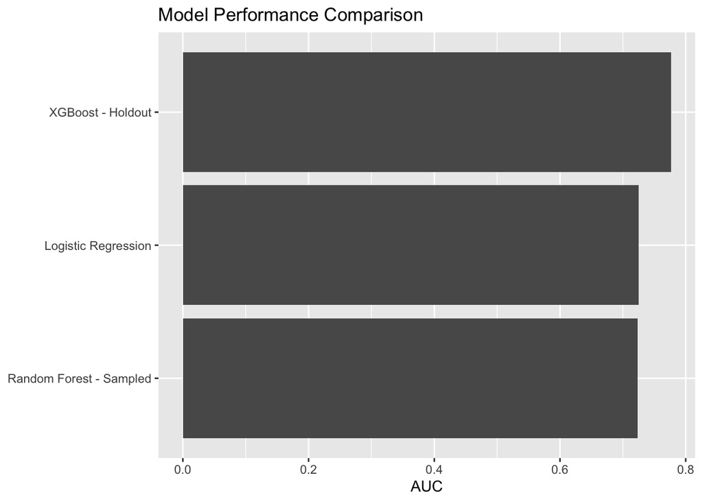

```r
ggplot(model_compare, aes(x = reorder(Model, AUC), y = AUC)) +
  geom_col() +
  coord_flip() +
  labs(
    title = "Model Performance Comparison",
    x = NULL,
    y = "AUC"
  )
```

This comparison shows whether more flexible models improve discrimination over the baseline. Logistic regression and random forest are compared using cross-validated AUC from caret. XGBoost is reported using holdout validation AUC because it was trained with the native xgboost interface rather than through caret. Random forest was fit on a subsample to keep runtime manageable on the large dummy-expanded feature matrix.

## 0.13 Class imbalance handling

Since only about 8% of applicants default, this notebook tests whether resampling improves discrimination. It compares a model with no sampling, downsampling, and upsampling.

```r
set.seed(123)
lr_none <- train(
  x = x_logit,
  y = y,
  method = "glm",
  family = "binomial",
  metric = "ROC",
  trControl = ctrl_cv
)

set.seed(123)
lr_down <- train(
  x = x_logit,
  y = y,
  method = "glm",
  family = "binomial",
  metric = "ROC",
  trControl = ctrl_down
)
set.seed(123)
lr_up <- train(
  x = x_logit,
  y = y,
  method = "glm",
  family = "binomial",
  metric = "ROC",
  trControl = ctrl_up
)
```

```r
imbalance_compare <- tibble(
  Strategy = c("None", "Downsampling", "Upsampling"),
  AUC = c(
    max(lr_none$results$ROC),
    max(lr_down$results$ROC),
    max(lr_up$results$ROC)
  )
)

imbalance_compare
```

| Strategy | AUC |
| --- | --- |
| None | 0.725085 |
| Downsampling | 0.725556 |
| Upsampling | 0.725525 |

If resampling improves AUC, it should be incorporated in later tuning. If not, it is reasonable to keep the original class distribution and rely on probability modeling rather than forced balancing.

## 0.14 Efficient tuning strategy

```r
## Efficient tuning strategy

set.seed(123)

tune_n <- min(5000, nrow(x_full))
tune_idx <- createDataPartition(y, p = tune_n / nrow(x_full), list = FALSE)

tune_x <- as.matrix(x_full[tune_idx, , drop = FALSE])
tune_y <- ifelse(y[tune_idx] == "Default", 1, 0)

dtrain_tune <- xgb.DMatrix(data = tune_x, label = tune_y)

xgb_grid <- data.frame(
  max_depth = c(4, 6, 4),
  eta = c(0.05, 0.05, 0.10),
  subsample = c(0.80, 0.80, 0.80),
  colsample_bytree = c(0.80, 0.80, 0.80),
  min_child_weight = c(1, 1, 1),
  nrounds = c(150, 150, 100)
)

xgb_tune_results <- tibble(
  max_depth = numeric(),
  eta = numeric(),
  subsample = numeric(),
  colsample_bytree = numeric(),
  min_child_weight = numeric(),
  best_nrounds = integer(),
  cv_auc = numeric()
)

for (i in seq_len(nrow(xgb_grid))) {
  params <- list(
    objective = "binary:logistic",
    eval_metric = "auc",
    max_depth = xgb_grid$max_depth[i],
    eta = xgb_grid$eta[i],
    subsample = xgb_grid$subsample[i],
    colsample_bytree = xgb_grid$colsample_bytree[i],
    min_child_weight = xgb_grid$min_child_weight[i]
  )

  cv_fit <- tryCatch(
    xgb.cv(
      params = params,
      data = dtrain_tune,
      nrounds = xgb_grid$nrounds[i],
      nfold = 3,
      early_stopping_rounds = 20,
      verbose = 0
    ),
    error = function(e) NULL
  )

  if (!is.null(cv_fit) &&
      !is.null(cv_fit$best_iteration) &&
      length(cv_fit$best_iteration) == 1 &&
      cv_fit$best_iteration > 0 &&
      "evaluation_log" %in% names(cv_fit)) {

    eval_log <- cv_fit$evaluation_log
    auc_col <- grep("test.*auc.*mean", names(eval_log), value = TRUE)[1]

    if (!is.na(auc_col) && length(auc_col) == 1) {
      xgb_tune_results <- bind_rows(
        xgb_tune_results,
        tibble(
          max_depth = xgb_grid$max_depth[i],
          eta = xgb_grid$eta[i],
          subsample = xgb_grid$subsample[i],
          colsample_bytree = xgb_grid$colsample_bytree[i],
          min_child_weight = xgb_grid$min_child_weight[i],
          best_nrounds = as.integer(cv_fit$best_iteration),
          cv_auc = as.numeric(eval_log[[auc_col]][cv_fit$best_iteration])
        )
      )
    }
  }
}

if (nrow(xgb_tune_results) == 0) {
  xgb_tune_results <- tibble(
    max_depth = 4,
    eta = 0.05,
    subsample = 0.80,
    colsample_bytree = 0.80,
    min_child_weight = 1,
    best_nrounds = 100L,
    cv_auc = NA_real_
  )
}

xgb_tune_results <- xgb_tune_results %>%
  arrange(desc(cv_auc))

xgb_tune_results
```

| max_depth | eta | subsample | colsample_bytree | min_child_weight | best_nrounds | cv_auc |
| --- | --- | --- | --- | --- | --- | --- |
| 4 | 0.05 | 0.8 | 0.8 | 1 | 100 | NA |

```r
best_xgb <- xgb_tune_results[1, ]
best_xgb
```

| max_depth | eta | subsample | colsample_bytree | min_child_weight | best_nrounds | cv_auc |
| --- | --- | --- | --- | --- | --- | --- |
| 4 | 0.05 | 0.8 | 0.8 | 1 | 100 | NA |

The randomized search is replaced here with a smaller manual grid because the native XGBoost interface is more stable than the `caret` wrapper on the large dummy-expanded Home Credit feature matrix.

## 0.15 Final model

```r
## Final model

final_x <- as.matrix(x_full)
final_y <- ifelse(y == "Default", 1, 0)

dfinal <- xgb.DMatrix(data = final_x, label = final_y)
dtest  <- xgb.DMatrix(data = as.matrix(test_x_full))

final_params <- list(
  objective = "binary:logistic",
  eval_metric = "auc",
  max_depth = best_xgb$max_depth,
  eta = best_xgb$eta,
  subsample = best_xgb$subsample,
  colsample_bytree = best_xgb$colsample_bytree,
  min_child_weight = best_xgb$min_child_weight
)

set.seed(123)
final_model <- xgb.train(
  params = final_params,
  data = dfinal,
  nrounds = best_xgb$best_nrounds,
  verbose = 0
)
```

## 0.16 Kaggle submission

```r
test_pred <- predict(final_model, dtest)

submission <- tibble(
  SK_ID_CURR = test_full_processed$SK_ID_CURR,
  TARGET = test_pred
)

write_csv(submission, "home_credit_submission.csv")
head(submission)
```

| SK_ID_CURR | TARGET |
| --- | --- |
| 100001 | 0.04066111 |
| 100005 | 0.18416657 |
| 100013 | 0.03779539 |
| 100028 | 0.04475440 |
| 100038 | 0.16400577 |
| 100042 | 0.06875826 |

After uploading the submission to Kaggle, record the public leaderboard score below.

**Kaggle public score:** Public .76421

## 0.17 Final results summary

# 1 Executive Summary

This model is strong enough to support underwriting decisions, but it should be used as a **decision-support tool**, not as a fully autonomous approval engine. The model can help sort applications into lower-risk and higher-risk groups, but deployment should still include human review, adverse-action controls, and fairness monitoring.

The model card below does three things a plain modeling notebook does not. First, it converts model probabilities into an operational threshold. Second, it explains the model using SHAP so a reviewer can see *why* risk rises or falls. Third, it checks whether approval rates differ meaningfully across demographic groups that deserve monitoring.

# 2 1. Model Details

## 2.1 Model identity

| Item | Value |
| --- | --- |
| Project | Home Credit Default Risk |
| Model card version | 1.0 |
| Model type | XGBoost binary classifier |
| Outcome predicted | Probability of repayment difficulty / default |
| Primary metric | AUC |
| Recorded Kaggle public AUC | 0.76421 |

## 2.2 Training data summary

This model uses the main application table plus engineered borrower-level aggregates from the supplementary credit-behavior tables used in the modeling notebook. The final training matrix reflects:

- applicant financial and demographic attributes from the application table,
- external credit signals such as the `EXT_SOURCE_*` variables,
- bureau-based indicators of active credit, debt burden, and overdue balances,
- installment payment behavior such as percent late and days past due,
- credit-card utilization and delinquency history, and
- POS cash repayment behavior.

| Measure | Value |
| --- | --- |
| Training rows | 307,511 |
| Model features after encoding | 112 |
| Observed default rate | 8.07% |

## 2.3 Final hyperparameters

| Parameter | Value |
| --- | --- |
| max_depth | 4e+00 |
| eta | 5e-02 |
| subsample | 8e-01 |
| colsample_bytree | 8e-01 |
| min_child_weight | 1e+00 |
| nrounds | 1e+02 |

# 3 2. Intended Use

This model is intended for a lending business audience deciding how to handle incoming applications. It is appropriate for:

- ranking applicants by predicted default risk,
- supporting approve / review / decline decisions,
- setting a threshold that reflects portfolio economics, and
- helping analysts monitor portfolio quality over time.

It is **not** designed for:

- fully autonomous lending with no human review,
- setting loan pricing by itself,
- making causal claims about why a borrower defaults,
- replacing compliance review, or
- generating legally final adverse-action notices without validation by risk and compliance teams.

# 4 3. Performance Metrics

The modeling notebook emphasized AUC because the target is strongly imbalanced. That remains the correct primary metric here. Accuracy alone would be misleading because a model can look accurate while still failing to identify the minority default class.

[output not shown]

The Kaggle score is useful because it reflects performance on unseen competition data. The internal holdout AUC is included here because Kaggle does not report precision or recall, and the model card needs threshold-based operating metrics.

# 5 4. Decision Threshold Analysis

A lending score becomes operational only when it is tied to a threshold. Because this version of the model card is restricted to the **Home Credit Kaggle data only**, the threshold is selected from observed model performance on an internal holdout sample rather than from external dollar assumptions.

This keeps the analysis fully grounded in the project dataset. The threshold below is chosen to balance default detection against approval volume by maximizing the **F1 score** on the holdout sample. F1 is useful here because the target is imbalanced and the business problem requires both identifying risky borrowers and avoiding too many false alarms.

## 5.1 Recommended operating threshold

Using the internal holdout sample, the recommended operating threshold is:

Recommended threshold: 0.17

At this threshold, applicants with predicted default probability **at or above** the threshold are flagged as predicted default / decline candidates, while applicants **below** the threshold are treated as approval candidates.

## 5.2 Threshold sensitivity

| Threshold | Precision | Recall | Specificity | F1 score | Balanced accuracy | Approval rate | Predicted default rate |
| --- | --- | --- | --- | --- | --- | --- | --- |
| 0.17 | 27.5% | 36.7% | 91.5% | 0.315 | 64.1% | 89.2% | 10.8% |

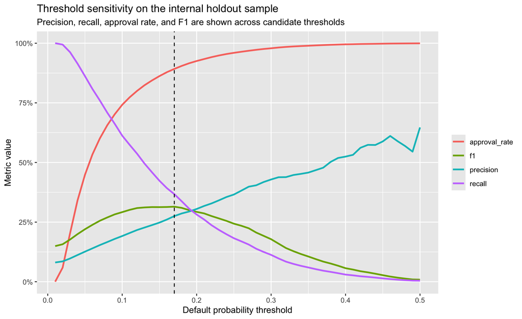

| Threshold | Precision | Recall | Specificity | F1 score | Approval rate |
| --- | --- | --- | --- | --- | --- |
| 0.17 | 27.5% | 36.7% | 91.5% | 0.315 | 89.2% |
| 0.16 | 26.1% | 39.3% | 90.2% | 0.313 | 87.8% |
| 0.14 | 23.7% | 45.9% | 87.1% | 0.313 | 84.4% |
| 0.15 | 24.8% | 42.4% | 88.7% | 0.313 | 86.2% |
| 0.13 | 22.7% | 49.5% | 85.2% | 0.312 | 82.4% |
| 0.18 | 28.6% | 33.7% | 92.6% | 0.310 | 90.5% |
| 0.12 | 21.7% | 53.7% | 83.0% | 0.309 | 80.0% |
| 0.11 | 20.4% | 57.4% | 80.4% | 0.301 | 77.3% |
| 0.19 | 29.4% | 30.6% | 93.6% | 0.300 | 91.6% |
| 0.20 | 30.5% | 28.2% | 94.4% | 0.293 | 92.5% |

This threshold recommendation is based entirely on observed predictive behavior within the Home Credit project data. It should be interpreted as a **model operating point**, not as a full profit-maximizing business rule, because the competition dataset does not include lender profit, recovery, servicing-cost, or loss-severity fields.

# 6 5. Explainability (SHAP)

SHAP explains *why* the model raises or lowers a prediction. Instead of only reporting a risk score, SHAP decomposes each prediction into feature-level contributions. For a lending use case, that matters because a business stakeholder needs to know whether the model is relying on sensible drivers of risk rather than only seeing a probability.

Consistent with the assignment instructions, SHAP is calculated on a **1,000-row sample** for speed.

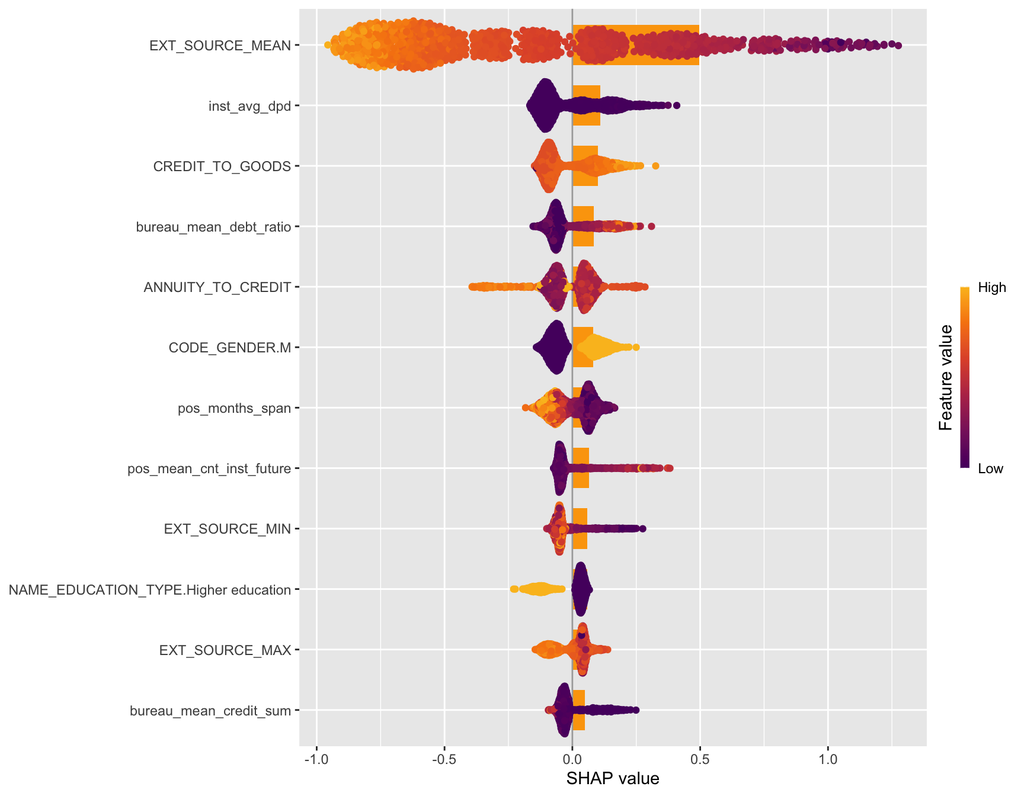

| Feature | Mean \|SHAP\| | Business meaning |
| --- | --- | --- |
| EXT_SOURCE_MEAN | 0.4964 | Limited or weaker external credit history |
| inst_avg_dpd | 0.1103 | Past installment payments were often late |
| CREDIT_TO_GOODS | 0.0989 | Loan amount is high relative to the value of goods financed |
| bureau_mean_debt_ratio | 0.0835 | Existing debt burden appears high relative to total credit |
| ANNUITY_TO_CREDIT | 0.0825 | Loan payment structure appears expensive relative to loan size |
| CODE_GENDER.M | 0.0812 | Code gender.m contributed to higher predicted risk |
| pos_months_span | 0.0680 | Pos months span contributed to higher predicted risk |
| pos_mean_cnt_inst_future | 0.0656 | Pos mean cnt inst future contributed to higher predicted risk |
| EXT_SOURCE_MIN | 0.0589 | At least one external credit signal is especially weak |
| NAME_EDUCATION_TYPE.Higher education | 0.0587 | Name education type.higher education contributed to higher predicted risk |

In plain language, the model’s strongest signals should be interpreted as **risk indicators learned from historical data**, not as proof of causation. A feature can be highly predictive because it captures real repayment behavior, because it stands in for another unobserved risk factor, or because it partly reflects historical bias in the data.

# 7 6. Adverse Action Mapping

If the model is ever used to support adverse decisions, the technical feature names must be translated into understandable reasons that a consumer can actually read. In practice, that means the feature names below should be converted into plain-language denial reasons rather than shown exactly as coded in the dataset.

| Technical feature | Suggested consumer-facing reason |
| --- | --- |
| EXT_SOURCE_MEAN | Limited or weaker external credit history |
| inst_avg_dpd | Past installment payments were often late |
| CREDIT_TO_GOODS | Loan amount is high relative to the value of goods financed |
| bureau_mean_debt_ratio | Existing debt burden appears high relative to total credit |
| ANNUITY_TO_CREDIT | Loan payment structure appears expensive relative to loan size |
| CODE_GENDER.M | Code gender.m contributed to higher predicted risk |
| pos_months_span | Pos months span contributed to higher predicted risk |
| pos_mean_cnt_inst_future | Pos mean cnt inst future contributed to higher predicted risk |
| EXT_SOURCE_MIN | At least one external credit signal is especially weak |
| NAME_EDUCATION_TYPE.Higher education | Name education type.higher education contributed to higher predicted risk |

These mappings are a starting point for model governance, not a final compliance artifact. Before deployment, legal and compliance reviewers should confirm that the final denial reasons are both accurate and sufficiently specific for the lender’s actual decision process.

# 8 7. Fairness Analysis

The assignment specifically requests approval-rate comparisons by `CODE_GENDER` and `NAME_EDUCATION_TYPE` at the chosen threshold. Those comparisons are shown below using the same internal holdout sample used for the threshold analysis.

## 8.1 Approval rates by gender

| CODE_GENDER | Applicants | ApprovalRate | ObservedDefaultRate |
| --- | --- | --- | --- |
| F | 40,380 | 91.4% | 7.0% |
| M | 21,121 | 85.0% | 10.1% |
| Missing | 1 | 100.0% | 0.0% |

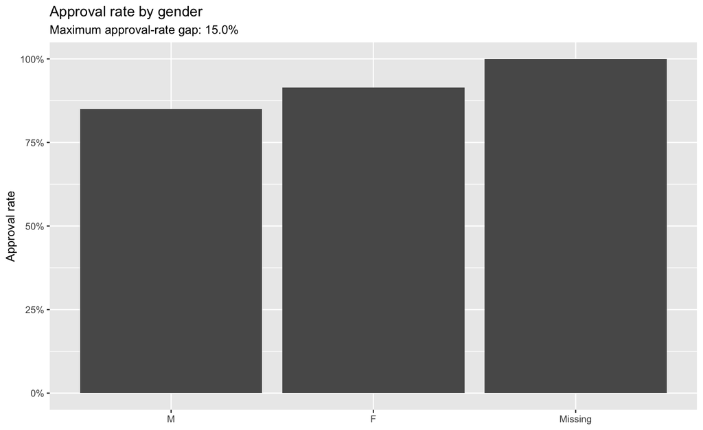

## 8.2 Approval rates by education level

| NAME_EDUCATION_TYPE | Applicants | ApprovalRate | ObservedDefaultRate |
| --- | --- | --- | --- |
| Secondary / secondary special | 43,649 | 87.5% | 9.0% |
| Higher education | 15,057 | 94.6% | 5.2% |
| Incomplete higher | 2,018 | 86.4% | 8.7% |
| Lower secondary | 746 | 85.8% | 11.0% |
| Academic degree | 32 | 96.9% | 0.0% |

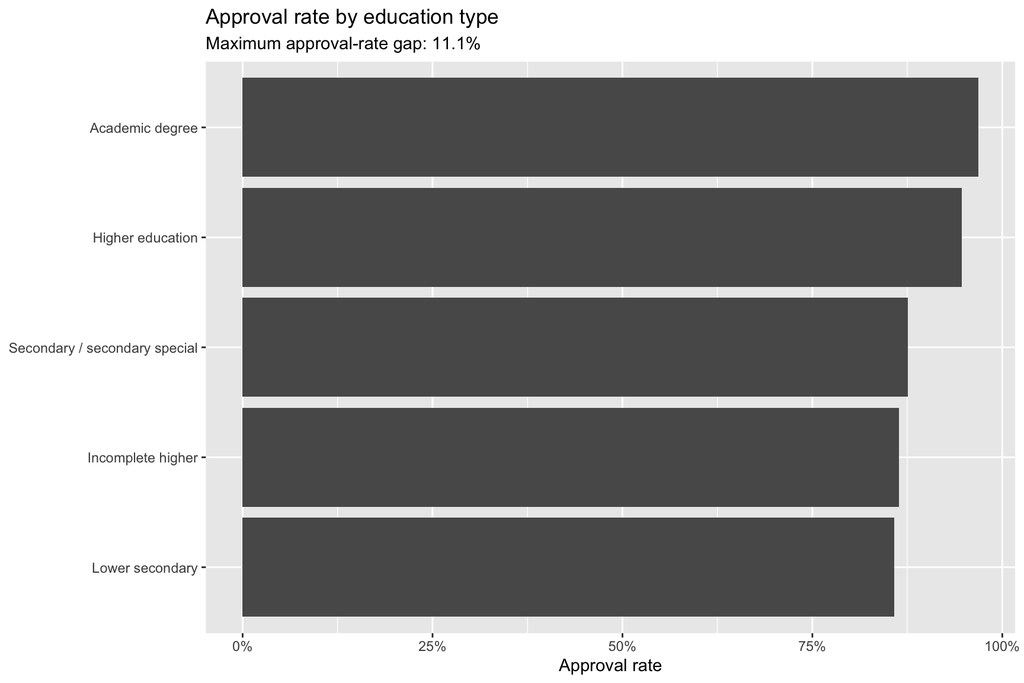

Any meaningful disparity here deserves follow-up. A disparity does not automatically prove unlawful discrimination, but it does indicate that the model is not operationally neutral across groups. That should trigger additional review before deployment, especially if the model is being used in a lending context.

# 9 8. Limitations and Risks

This model has several important limitations.

First, it was trained on historical application and repayment data. Historical data can encode historical underwriting patterns, missingness, and structural bias. Strong predictive performance does not guarantee fair treatment.

Second, the threshold analysis is deliberately limited to what can be learned from the Home Credit dataset itself. The recommended threshold is supported by holdout-sample classification performance, but the dataset does not include lender profit, recovery, servicing-cost, or capital-cost fields. That means the threshold should be treated as an analytical operating point rather than a complete deployment economics rule.

Third, the model is predictive rather than causal. A SHAP explanation shows which features influenced the score; it does not prove that those features caused repayment trouble.

Fourth, the data available to the model are incomplete. The model does not observe every factor that may matter in repayment behavior, including changes in employment, shocks after origination, and any information not present in the competition dataset.

Finally, fairness analysis here is intentionally limited to the requested variables: gender and education type. A production deployment would require broader model risk management, including monitoring over time, segment drift checks, and validation by risk and compliance teams.

# 10 9. Business Recommendation

Based on the current evidence, this model is **good enough to support underwriting decisions in a human-in-the-loop setting**. It shows useful discrimination, it can be translated into a threshold-based approval rule, and its key drivers can be explained in business language.

The recommended next step is a controlled deployment in which the model is used to prioritize applications for approval, decline, or manual review rather than to replace underwriters entirely. The threshold should begin at **0.17**, then be revisited after additional validation using the lender’s live outcomes and governance process.

At the recommended threshold, the internal holdout analysis shows the following operating characteristics:

| Threshold | Precision | Recall | Specificity | F1 score | Approval rate |
| --- | --- | --- | --- | --- | --- |
| 0.17 | 27.5% | 36.7% | 91.5% | 0.315 | 89.2% |

This recommendation uses only the Home Credit Kaggle data and does not claim any dollar-impact estimate that is not directly supported by the dataset.